# Depressive symptoms (HADS-D) in adults with chronic disease

Dataset 9: Patient activation for self-management in chronic disease

RSR feasibility analysis

2026-08-03

# Introduction

Depressive symptoms are common in long-term physical illness and are associated with worse self-care, more hospital use and higher mortality. These data come from a cross-sectional survey of 1,154 Dutch adults treated in primary and secondary care for type 2 diabetes, COPD, chronic heart failure or chronic renal disease (Bos-Touwen et al., *PLoS ONE* 2015;10(5):e0126400), in which the Hospital Anxiety and Depression Scale was administered alongside measures of social and economic circumstances. Knowing which patients carry the heaviest symptom burden helps target psychological support in chronic-disease clinics.

**Aim.** Among Dutch adults with one of four chronic conditions, we examined which of age, sex, education, financial distress, index disease, comorbidity burden and perceived social support are independently associated with HADS depression score, mutually adjusting for the others.

This is a *Purpose 3* analysis: several predictors are of interest and the question is which remain associated with the outcome after mutual adjustment.

# Methods

**Data source.** Cross-sectional survey of adults with type 2 diabetes, COPD, chronic heart failure or chronic renal disease recruited from Dutch general practices and hospital outpatient clinics; 1154 participants, all measured on a single occasion.

**Variables.** The outcome is `hads_depression`, the HADS depression subscale scored 0-21, where higher means more depressive symptoms and a score of 8 or more is conventionally taken to suggest probable caseness. Predictors are `age_yrs` (years), `sex` (reference: male), `education_level` (reference: lower, the largest group), `financial_distress` (none / low / high, reference: none — the clinically “unexposed” group and the largest), `disease` (reference: type 2 diabetes, the largest group), `charlson_index` (points; higher = more comorbidity) and `social_support_total` (MSPSS total, 12-84; higher = more perceived support).

**Sibling scale deliberately excluded.** `hads_anxiety` is the other subscale of the same 14-item instrument, completed at the same sitting, and correlates 0.66 with the outcome. Entering it would give a variance-inflation factor of only 1.19 — collinearity is *not* the reason to leave it out — but adjusted R² would jump from 0.19 to 0.49, and essentially all of that gain is the HADS predicting itself. That is a restatement of the outcome, not an explanation of it, so `hads_anxiety` is excluded. `sf12_mental` is excluded for the same reason: it is a mental-health summary score that overlaps conceptually with HADS-D (r = -0.71). `bmi` in this file is exactly `weight_kg / (height_cm/100)^2`, so those three would never appear together; none is used here. `n_comorbidities` correlates 0.78 with `charlson_index`, so only the Charlson index is used.

**Statistical analysis.** Linear regression (`lm()`), justified because the outcome is a continuous 0-21 score. We fitted a univariable model for each predictor first, then a single multivariable model containing all of them. Predictors were chosen in advance on subject-matter grounds, not by significance. Significance threshold 0.05; estimates are reported with 95% confidence intervals. Assumptions were checked with `performance::check_model()`; because non-constant error variance was detected, heteroscedasticity-consistent (HC3) standard errors were also computed with `lmtest::coeftest()` and `sandwich::vcovHC()`. Analysis used R version 4.6.0 (2026-04-24) with tidyverse, gtsummary and performance.

**Missing data.** Complete-case analysis: 1056 of 1154 rows were analysed (98 dropped). Missing questionnaire answers were coded 99 in the original deposit, but that conversion to `NA` has already been applied in this CSV; a check across all numeric columns other than `id` found 0 remaining values equal to 99, so no further re-coding was needed.

# Results

## Sample characteristics

**Table 1. Sample characteristics.**

| **Characteristic** | **N** | **N = 1,056**<sup>1</sup> |
| --- | --- | --- |
| hads_depression | 1,056 | 4.0 (2.0, 8.0) |
| age_yrs | 1,056 | 70 (62, 78) |
| sex | 1,056 |  |
| Male |  | 647 (61%) |
| Female |  | 409 (39%) |
| education_level | 1,056 |  |
| Lower |  | 497 (47%) |
| Middle |  | 399 (38%) |
| Higher |  | 160 (15%) |
| financial_distress | 1,056 |  |
| None |  | 504 (48%) |
| Low |  | 465 (44%) |
| High |  | 87 (8.2%) |
| disease | 1,056 |  |
| Type 2 diabetes |  | 382 (36%) |
| COPD |  | 273 (26%) |
| Heart failure |  | 198 (19%) |
| Renal disease |  | 203 (19%) |
| charlson_index | 1,056 | 3.00 (1.00, 4.00) |
| social_support_total | 1,056 | 66 (54, 75) |

<sup>1</sup> Median (Q1, Q3); n (%)

The HADS depression distribution is strongly right-skewed: the median is 4 with an interquartile range of roughly 2 to 8, so most of this sample is well below the caseness threshold while a minority score in the teens. Financial distress is uncommon at the “high” level (fewer than one in ten), which makes that comparison the least precise in the model.

## Exploratory figure

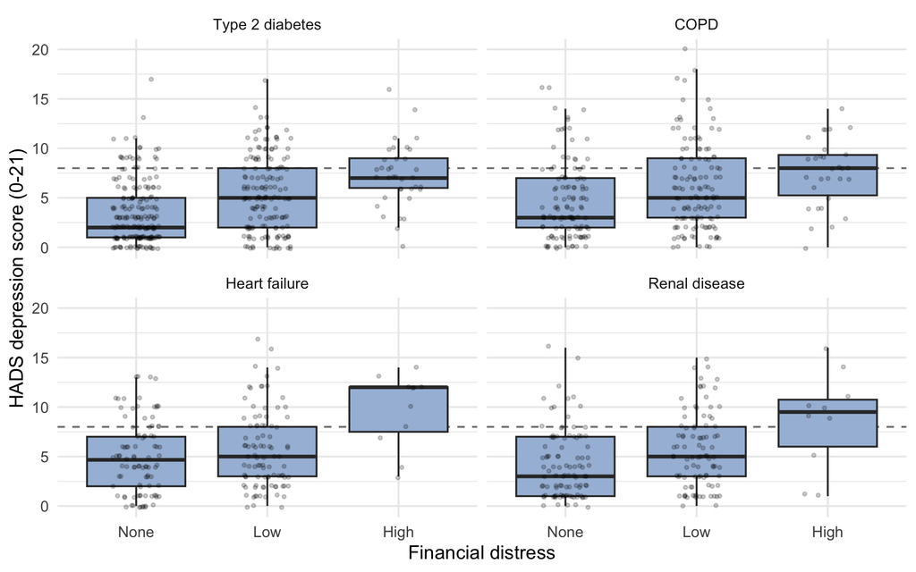

Figure 1. HADS depression score by self-reported financial distress, within index disease group. Boxes show medians and interquartile ranges; the dashed line is the caseness threshold of 8.

Depressive symptoms rise steadily across the three financial-distress categories, and the gradient is visible in all four disease groups, though the “high” group is small everywhere.

## Univariable models

| **Characteristic** | **N** | **Beta** | **95% CI** | **p-value** |
| --- | --- | --- | --- | --- |
| age_yrs | 1,056 | 0.04 | 0.02, 0.06 | <0.001 |
| sex | 1,056 |  |  |  |
| Male |  | — | — |  |
| Female |  | 0.55 | 0.07, 1.0 | 0.025 |
| education_level | 1,056 |  |  |  |
| Lower |  | — | — |  |
| Middle |  | -0.93 | -1.4, -0.43 | <0.001 |
| Higher |  | -2.1 | -2.8, -1.4 | <0.001 |
| financial_distress | 1,056 |  |  |  |
| None |  | — | — |  |
| Low |  | 1.5 | 1.1, 2.0 | <0.001 |
| High |  | 3.7 | 2.8, 4.5 | <0.001 |
| disease | 1,056 |  |  |  |
| Type 2 diabetes |  | — | — |  |
| COPD |  | 1.1 | 0.46, 1.7 | <0.001 |
| Heart failure |  | 0.99 | 0.32, 1.6 | 0.004 |
| Renal disease |  | 0.47 | -0.19, 1.1 | 0.2 |
| charlson_index | 1,056 | 0.43 | 0.30, 0.56 | <0.001 |
| social_support_total | 1,056 | -0.06 | -0.08, -0.05 | <0.001 |

Abbreviation: CI = Confidence Interval

## Why adjustment is needed

The crude associations here are heavily entangled. `education_level` is an obvious confounder of the financial-distress association: less-educated patients are both more likely to report financial distress and, independently, report more depressive symptoms, so part of the crude distress gradient is really educational disadvantage. `charlson_index` is a second: comorbidity burden rises with age (r = 0.34), differs sharply between the four disease groups, and is itself associated with depressive symptoms, so both the crude age association and the crude COPD/heart-failure associations partly reflect how sick these patients are overall rather than anything specific to age or diagnosis. `social_support_total` is a third candidate, since patients who live in financially precarious circumstances also report thinner support networks. And because the four disease groups were pooled by design and differ in age, sex mix and comorbidity, `disease` must be in the model for any other coefficient to be read as a within-disease comparison.

## Multivariable model

| **Characteristic** | **Beta** | **95% CI** | **p-value** |
| --- | --- | --- | --- |
| age_yrs | 0.02 | 0.00, 0.04 | 0.070 |
| sex |  |  |  |
| Male | — | — |  |
| Female | 0.38 | -0.07, 0.82 | 0.10 |
| education_level |  |  |  |
| Lower | — | — |  |
| Middle | -0.68 | -1.2, -0.21 | 0.005 |
| Higher | -1.4 | -2.0, -0.73 | <0.001 |
| financial_distress |  |  |  |
| None | — | — |  |
| Low | 1.1 | 0.64, 1.6 | <0.001 |
| High | 2.9 | 2.1, 3.8 | <0.001 |
| disease |  |  |  |
| Type 2 diabetes | — | — |  |
| COPD | 0.77 | 0.22, 1.3 | 0.006 |
| Heart failure | 0.46 | -0.19, 1.1 | 0.2 |
| Renal disease | -0.24 | -0.90, 0.42 | 0.5 |
| charlson_index | 0.39 | 0.25, 0.53 | <0.001 |
| social_support_total | -0.05 | -0.07, -0.04 | <0.001 |

Abbreviation: CI = Confidence Interval

Model fit

| Statistic | Value |
| --- | --- |
| R-squared | 0.194 |
| Adjusted R-squared | 0.186 |
| Residual SE | 3.500 |
| N | 1056.000 |
| Model df | 11.000 |

Conditional on all other predictors, high financial distress remains associated with a 2.94-point higher HADS depression score than no distress (95% CI 2.11 to 3.78, p < 0.001) and low distress with a 1.10-point increase (95% CI 0.64 to 1.55, p < 0.001). Each additional point of perceived social support is associated with a 0.054-point lower score (95% CI -0.068 to -0.040, p < 0.001), and each Charlson point with a 0.39-point higher score (95% CI 0.25 to 0.53, p < 0.001). Higher education retains a 1.39-point advantage over lower education (95% CI -2.04 to -0.73, p < 0.001). Age (p = 0.070) and sex (p = 0.097) are no longer associated once socioeconomic circumstances and comorbidity are held constant. The model explains R² = 0.194 of the variance (adjusted R² = 0.186).

## Unadjusted versus adjusted

**Table 2. Unadjusted and adjusted estimates.**

| **Characteristic** | **Unadjusted** **N** | **Unadjusted** **Beta** | **Unadjusted** **95% CI** | **Unadjusted** **p-value** | **Adjusted** **Beta** | **Adjusted** **95% CI** | **Adjusted** **p-value** |
| --- | --- | --- | --- | --- | --- | --- | --- |
| age_yrs | 1,056 | 0.04 | 0.02, 0.06 | <0.001 | 0.02 | 0.00, 0.04 | 0.070 |
| sex | 1,056 |  |  |  |  |  |  |
| Male |  | — | — |  | — | — |  |
| Female |  | 0.55 | 0.07, 1.0 | 0.025 | 0.38 | -0.07, 0.82 | 0.10 |
| education_level | 1,056 |  |  |  |  |  |  |
| Lower |  | — | — |  | — | — |  |
| Middle |  | -0.93 | -1.4, -0.43 | <0.001 | -0.68 | -1.2, -0.21 | 0.005 |
| Higher |  | -2.1 | -2.8, -1.4 | <0.001 | -1.4 | -2.0, -0.73 | <0.001 |
| financial_distress | 1,056 |  |  |  |  |  |  |
| None |  | — | — |  | — | — |  |
| Low |  | 1.5 | 1.1, 2.0 | <0.001 | 1.1 | 0.64, 1.6 | <0.001 |
| High |  | 3.7 | 2.8, 4.5 | <0.001 | 2.9 | 2.1, 3.8 | <0.001 |
| disease | 1,056 |  |  |  |  |  |  |
| Type 2 diabetes |  | — | — |  | — | — |  |
| COPD |  | 1.1 | 0.46, 1.7 | <0.001 | 0.77 | 0.22, 1.3 | 0.006 |
| Heart failure |  | 0.99 | 0.32, 1.6 | 0.004 | 0.46 | -0.19, 1.1 | 0.2 |
| Renal disease |  | 0.47 | -0.19, 1.1 | 0.2 | -0.24 | -0.90, 0.42 | 0.5 |
| charlson_index | 1,056 | 0.43 | 0.30, 0.56 | <0.001 | 0.39 | 0.25, 0.53 | <0.001 |
| social_support_total | 1,056 | -0.06 | -0.08, -0.05 | <0.001 | -0.05 | -0.07, -0.04 | <0.001 |

Abbreviation: CI = Confidence Interval

Two estimates move a long way towards the null. High financial distress falls from +3.69 to +2.94 and low distress from +1.54 to +1.10, so roughly a quarter of the crude socioeconomic gradient in depressive symptoms is accounted for by education, comorbidity and social support — but three-quarters of it survives. The disease coefficients also shrink: COPD from +1.06 to +0.77 (still significant, p = 0.006), heart failure from +0.99 to +0.46 (now non-significant, p = 0.16) and renal disease from +0.47 to -0.24, i.e. the heart-failure excess is largely explained by comorbidity burden. Two predictors change significance: age (p < 0.001 crude to p = 0.070 adjusted) and sex (p = 0.025 to p = 0.097), both attenuated by the Charlson index and by socioeconomic variables respectively. Social support barely moves (-0.061 to -0.054) and the Charlson index only modestly (0.43 to 0.39), which indicates these two carry information not duplicated by the rest of the model. The overall picture is classic confounding by socioeconomic position and comorbidity rather than mediation or collinearity — all VIFs are below 1.5.

## Diagnostics

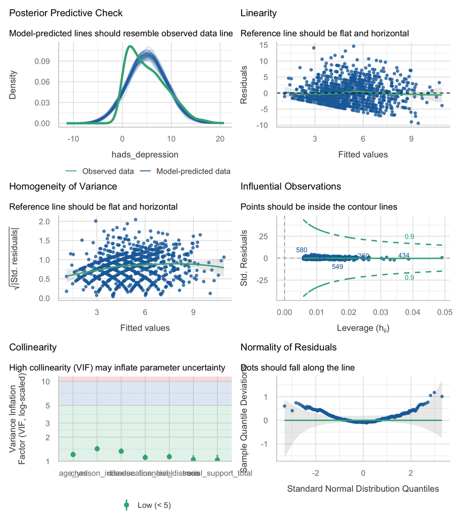

| Term | VIF | VIF_CI_low | VIF_CI_high | SE_factor | Tolerance | Tolerance_CI_low | Tolerance_CI_high |
| --- | --- | --- | --- | --- | --- | --- | --- |
| age_yrs | 1.211931 | 1.142109 | 1.316057 | 1.100877 | 0.8251295 | 0.7598453 | 0.8755729 |
| sex | 1.047975 | 1.012326 | 1.186720 | 1.023706 | 0.9542216 | 0.8426588 | 0.9878238 |
| education_level | 1.112397 | 1.058780 | 1.214920 | 1.026987 | 0.8989598 | 0.8230994 | 0.9444831 |
| financial_distress | 1.138123 | 1.079718 | 1.239320 | 1.032874 | 0.8786393 | 0.8068944 | 0.9261678 |
| disease | 1.332596 | 1.246929 | 1.447985 | 1.049018 | 0.7504148 | 0.6906150 | 0.8019704 |
| charlson_index | 1.430001 | 1.332445 | 1.556186 | 1.195827 | 0.6993000 | 0.6425967 | 0.7505002 |
| social_support_total | 1.038069 | 1.007084 | 1.204584 | 1.018857 | 0.9633271 | 0.8301620 | 0.9929660 |

Because heteroscedasticity was flagged, the model was re-tested with HC3 heteroscedasticity-consistent standard errors:

HC3 robust standard errors

Compared with the model-based standard errors

| Term | Estimate | Model SE | HC3 SE | HC3 p |
| --- | --- | --- | --- | --- |
| (Intercept) | 5.361 | 0.928 | 0.977 | <0.001 |
| age_yrs | 0.020 | 0.011 | 0.011 | 0.0737 |
| sexFemale | 0.376 | 0.227 | 0.228 | 0.0993 |
| education_levelMiddle | -0.681 | 0.239 | 0.245 | 0.0056 |
| education_levelHigher | -1.386 | 0.334 | 0.311 | <0.001 |
| financial_distressLow | 1.095 | 0.232 | 0.235 | <0.001 |
| financial_distressHigh | 2.941 | 0.425 | 0.425 | <0.001 |
| diseaseCOPD | 0.768 | 0.280 | 0.294 | 0.0092 |
| diseaseHeart failure | 0.461 | 0.329 | 0.328 | 0.1599 |
| diseaseRenal disease | -0.239 | 0.335 | 0.319 | 0.4542 |
| charlson_index | 0.389 | 0.071 | 0.075 | <0.001 |
| social_support_total | -0.054 | 0.007 | 0.008 | <0.001 |

# Discussion

Among Dutch adults with one of four chronic conditions, self-reported financial distress is the characteristic most strongly and independently associated with depressive symptoms, followed by low perceived social support, higher comorbidity burden and lower education. Index disease adds little once these are accounted for, and age and sex add nothing. Practically, this argues for asking about money worries and social isolation in chronic-disease review appointments, since these mark out patients at psychological risk far better than the diagnosis does.

**Limitations.** The design is cross-sectional, so the direction of the financial-distress and social-support associations cannot be established: depression could plausibly cause a person to perceive their finances and their support network more negatively, which is exactly the reverse of the causal story above. Financial distress and social support are self-reported on the same questionnaire occasion as the HADS, so common-method bias will inflate those associations. The file has no disease-specific severity markers — no eGFR or dialysis status, no NYHA class, no GOLD stage — so severity is proxied only by the generic Charlson index and residual confounding by severity is likely. The “high” financial-distress cell contains fewer than 100 people, so that estimate is the least precise. Error variance is non-constant and residuals are non-normal; HC3 standard errors were reported and changed nothing, but a count or ordinal model would be a more principled fit for a floor-bounded 0-21 score. Complete-case analysis dropped 98 participants (8.5%), and non-response to mood items is plausibly related to mood itself. All estimates are associations, not effects.

**Future work.** A longitudinal design measuring financial circumstances and mood repeatedly would separate the “poverty causes distress” and “distress colours reporting” explanations.

# Feasibility notes

*Not part of a student report.*

- **Works well, with one assumption caveat.** Real socioeconomic gradients, a clean dose-response in `financial_distress`, and a good mix of predictors that survive and predictors that disappear after adjustment.
- **Complete-case N = 1056** of 1154 (98 dropped, 8.5% — the largest loss of the five outcomes here, driven mainly by `financial_distress` and the HADS items themselves).
- **Heteroscedasticity is genuinely flagged** (p < 0.001) and normality is rejected. This is a feature, not a bug, for teaching: it forces the student through `check_heteroscedasticity()` and HC3 robust SEs. The robust SEs are almost identical to the model-based ones, so the conclusions are stable and the student does not end up with a broken analysis.
- **The sibling-scale trap is live.** `hads_anxiety` gives VIF 1.19 — students will look at the VIF, see no collinearity, and keep it. Adjusted R² then goes from 0.186 to 0.485 and the “finding” is that the HADS predicts the HADS. `sf12_mental` (r = -0.71) is the same trap in a different costume. Both need to be explicitly ruled out in the brief.
- **No collinearity problem** in the chosen set: max VIF 1.43.
- **Sparse cell**: `financial_distress = high` has fewer than 100 participants; fine for a main effect, hopeless for an interaction.